# Chained Model Walkthrough: Syria

# Forecasting Syria Data

This is a chain of simple forecast models. The data has been imputed, aggregated by Zone of Control, and log-transformed.

```r
knitr::opts_chunk$set(message = FALSE, warning = FALSE, echo = TRUE)
data_tbl = read_csv("syria_forecast_set.csv")
head(data_tbl)
```

```
## # A tibble: 6 × 3
##   date       id                                               value
##   <date>     <chr>                                            <dbl>
## 1 2018-01-01 Alcohol (spray)-200 ML|Autonomous Administration  5.19
## 2 2018-02-01 Alcohol (spray)-200 ML|Autonomous Administration  5.42
## 3 2018-03-01 Alcohol (spray)-200 ML|Autonomous Administration  4.77
## 4 2018-04-01 Alcohol (spray)-200 ML|Autonomous Administration  5.21
## 5 2018-05-01 Alcohol (spray)-200 ML|Autonomous Administration  5.52
## 6 2018-06-01 Alcohol (spray)-200 ML|Autonomous Administration  6.12
```

## Stage One: Naive

The model chain begins with a Naive Forecast as the first stage and includes a 12 month test set. The predicted values from the Naive model are fed into the next stage.

```r
  splits <- data_tbl %>%
    time_series_split(
      assess     = "12 months",
      cumulative = TRUE
    )

  future_tbl <- data_tbl %>%
    dplyr::group_by(id) %>%
    future_frame(.length_out = 12, .bind_data = FALSE)

  model_spec <- naive_reg(id = "id", seasonal_period = "1 month") %>%
    set_engine("snaive") %>%
    fit(value ~ date + id, data = testing(splits))

  model_tbl <- modeltime_table(
    model_spec
  )


  calib_tbl <- model_tbl %>%
    modeltime_calibrate(
      new_data = testing(splits),
      id       = "id"
    )
```

```r
  naive_preds = predict(model_spec, data_tbl)

  preds = cbind(data_tbl,
                naive = naive_preds$.pred) %>%
    dplyr::select(c(naive, date, id, value)) %>%
    dplyr::mutate(id = as.factor(id))

  naive_preds = predict(model_spec, future_tbl)

  fc_set = cbind(future_tbl,
                 naive = naive_preds$.pred) %>%
    dplyr::select(c(naive, date, id)) %>%
    dplyr::mutate(id = as.factor(id))

head(fc_set)
```

```
## # A tibble: 6 × 3
## # Groups:   id [1]
##   naive date       id
##   <dbl> <date>     <fct>
## 1  7.88 2023-05-01 Alcohol (spray)-200 ML|Autonomous Administration
## 2  7.88 2023-06-01 Alcohol (spray)-200 ML|Autonomous Administration
## 3  7.88 2023-07-01 Alcohol (spray)-200 ML|Autonomous Administration
## 4  7.88 2023-08-01 Alcohol (spray)-200 ML|Autonomous Administration
## 5  7.88 2023-09-01 Alcohol (spray)-200 ML|Autonomous Administration
## 6  7.88 2023-10-01 Alcohol (spray)-200 ML|Autonomous Administration
```

## Stage Two: Cubist

```r
  splits <- preds %>%
    time_series_split(
      assess     = "12 months",
      cumulative = TRUE
    )

  rec_obj <- recipe(value ~ ., training(splits)) %>%
    step_mutate_at(id, fn = droplevels) %>%
    step_timeseries_signature(date) %>%
    step_rm(date) %>%
    step_zv(all_predictors()) %>%
    step_dummy(all_nominal_predictors(), one_hot = TRUE)


  model_spec <- cubist_rules(mode = "regression", committees = 20, neighbors = 5, max_rules = 15) %>%
    set_engine("Cubist")


  wflw_fit_cubist <- workflow() %>%
    add_recipe(rec_obj) %>%
    add_model(model_spec) %>%
    fit(training(splits))


  model_tbl <- modeltime_table(
    wflw_fit_cubist
  )

  ## This is making predictions on the test set and collecting accuracy metrics
  calib_tbl <- model_tbl %>%
    modeltime_calibrate(
      new_data = testing(splits),
      id       = "id"
    )

  test_fc = calib_tbl %>%
    modeltime_forecast(
      new_data    = testing(splits),
      actual_data = preds,
      conf_by_id  =TRUE
    )
```

#### Model Metrics on Test Set

```r
  calib_tbl %>%
    modeltime_accuracy(acc_by_id = FALSE) %>%
    table_modeltime_accuracy(.interactive = FALSE)
```

Accuracy Table

| .model_id | .model_desc | .type | mae | mape | mase | smape | rmse | rsq |
| --- | --- | --- | --- | --- | --- | --- | --- | --- |
| 1 | CUBIST | Test | 0.34 | 4.05 | 0.17 | 4.15 | 0.43 | 0.96 |

#### Test Set Performance on Three Random Commodities

[output not shown]

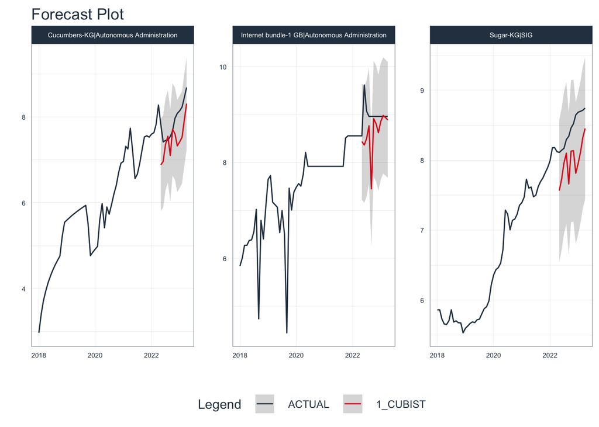

```r
test_fc %>%
    dplyr::filter(id %in% sample(unique(id),3)) %>%
    group_by(id) %>%
    plot_modeltime_forecast(
      .facet_ncol  = 3,
      .interactive = FALSE
    )
```

Cubist predictions and forecasts (as well as smoothed predictions and forecasts) are bundled with the Naive predictions and forecasts, then passed on as inputs to the XGBoost Model.

#### Round 2 Predictions

```r
refit_tbl <- calib_tbl %>%
    modeltime_refit(data = preds)

  cub_preds = refit_tbl %>%
    modeltime_forecast(
      new_data    = preds,
      actual_data = preds,
      conf_by_id  =TRUE
    )

  cub_preds = cub_preds %>%
    dplyr::select(key = .key, date = .index, value = .value, id) %>%
    tidyr::pivot_wider(names_from = key, values_from = value) %>%
    group_by(id) %>%
    mutate(prediction_smoothed = slider::slide_dbl(prediction, mean, .before = 3, .after = 1)) %>%
    dplyr::rename(value = actual,
                  cub = prediction,
                  cub_smoothed = prediction_smoothed)

  round2_preds = base::merge(cub_preds, preds)

  cub_fc = refit_tbl %>%
    modeltime_forecast(
      new_data    = fc_set,
      actual_data = preds,
      conf_by_id  =TRUE
    )

  fc_set_cub = cub_fc %>%
    dplyr::filter(.key != "actual") %>%
    dplyr::filter(!is.na(.value)) %>%
    group_by(id) %>%
    mutate(prediction = slider::slide_dbl(.value, mean, .before = 2, .after = 1)) %>%
    dplyr::rename(cub = .value) %>%
    dplyr::select(c(cub, cub_smoothed = prediction, date = .index, id))

  round2_fc = base::merge(fc_set, fc_set_cub)
head(round2_preds)
```

```
##         date                                               id    value      cub
## 1 2018-01-01 Alcohol (spray)-200 ML|Autonomous Administration 5.186154 5.407777
## 2 2018-01-01                       Alcohol (spray)-200 ML|SIG 6.708360 6.652985
## 3 2018-01-01                       Alcohol (spray)-200 ML|SSG 6.956704 6.917867
## 4 2018-01-01         Alcohol (spray)-200 ML|Syrian Government 6.855958 6.621081
## 5 2018-01-01              Apples-KG|Autonomous Administration 5.587249 5.706731
## 6 2018-01-01                                    Apples-KG|SIG 5.860786 5.848098
##   cub_smoothed    naive
## 1     5.446313 7.879994
## 2     7.670269 8.794976
## 3     8.020313 8.640720
## 4     7.633304 8.601456
## 5     7.011737 8.568456
## 6     7.576303 8.555837
```

## Stage Three: XGBoost

The XGBoost model uses the same pre-processing steps as the Cubist model. It has a maximum of 2500 trees, samples 65% at each training iteration, allows a maximum tree-depth of three, a learning rate of 0.07, and stops training if it hasn’t seen improvement in 5 rounds.

```r
splits <- round2_preds %>%
    time_series_split(
      assess     = "12 months",
      cumulative = TRUE
    )

  rec_obj <- recipe(value ~ ., training(splits)) %>%
    step_mutate_at(id, fn = droplevels) %>%
    step_timeseries_signature(date) %>%
    step_rm(date) %>%
    step_zv(all_predictors()) %>%
    step_dummy(all_nominal_predictors(), one_hot = TRUE)

  wflw_xgb <- workflow() %>%
    add_model(
      boost_tree("regression",
                 sample_size = 0.65, trees = 2500, learn_rate = 0.07, stop_iter = 5, tree_depth = 3) %>%
        set_engine("xgboost")) %>%
    add_recipe(rec_obj) %>%
    fit(training(splits))


  model_tbl <- modeltime_table(
    wflw_xgb
  )

  calib_tbl <- model_tbl %>%
    modeltime_calibrate(
      new_data = testing(splits),
      id       = "id"
    )
```

#### Model Metrics on Test Set

```r
  calib_tbl %>%
    modeltime_accuracy(acc_by_id = FALSE) %>%
    table_modeltime_accuracy(.interactive = FALSE)
```

Accuracy Table

| .model_id | .model_desc | .type | mae | mape | mase | smape | rmse | rsq |
| --- | --- | --- | --- | --- | --- | --- | --- | --- |
| 1 | XGBOOST | Test | 0.1 | 1.21 | 0.14 | 1.2 | 0.14 | 1 |

#### Test Set Performance on Three Random Commodities

[output not shown]

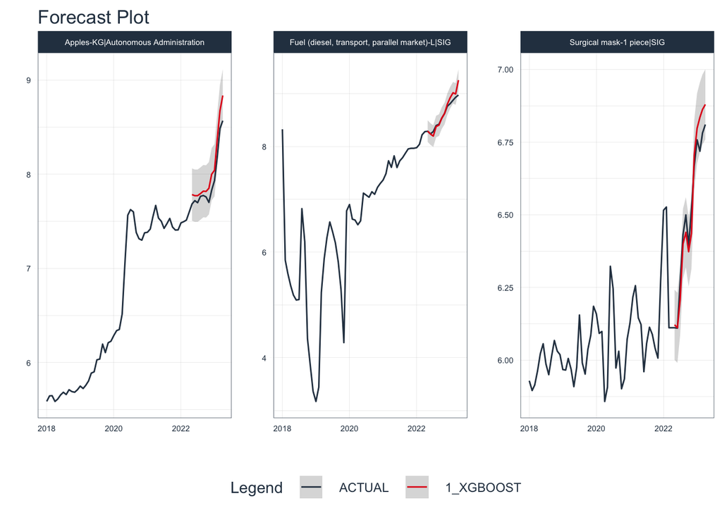

```r
test_fc = calib_tbl %>%
    modeltime_forecast(
      new_data    = testing(splits),
      actual_data = round2_preds,
      conf_by_id  =TRUE
    )

test_fc %>%
    dplyr::filter(id %in% sample(unique(id),3)) %>%
    group_by(id) %>%
    plot_modeltime_forecast(
      .facet_ncol  = 3,
      .interactive = FALSE
    )
```

#### Fit Details

```r
wflw_xgb$fit
```

```
## $actions
## $actions$model
## $spec
## Boosted Tree Model Specification (regression)
##
## Main Arguments:
##   trees = 2500
##   tree_depth = 3
##   learn_rate = 0.07
##   sample_size = 0.65
##   stop_iter = 5
##
## Computational engine: xgboost
##
##
## $formula
## NULL
##
## attr(,"class")
## [1] "action_model" "action_fit"   "action"
##
##
## $fit
## parsnip model object
##
## ##### xgb.Booster
## raw: 2.8 Mb
## call:
##   xgboost::xgb.train(params = list(eta = 0.07, max_depth = 3, gamma = 0,
##     colsample_bytree = 1, colsample_bynode = 1, min_child_weight = 1,
##     subsample = 0.65), data = x$data, nrounds = 2500, watchlist = x$watchlist,
##     verbose = 0, early_stopping_rounds = 5, nthread = 1, objective = "reg:squarederror")
## params (as set within xgb.train):
##   eta = "0.07", max_depth = "3", gamma = "0", colsample_bytree = "1", colsample_bynode = "1", min_child_weight = "1", subsample = "0.65", nthread = "1", objective = "reg:squarederror", validate_parameters = "TRUE"
## xgb.attributes:
##   best_iteration, best_msg, best_ntreelimit, best_score, niter
## callbacks:
##   cb.evaluation.log()
##   cb.early.stop(stopping_rounds = early_stopping_rounds, maximize = maximize,
##     verbose = verbose)
## # of features: 267
## niter: 2500
## best_iteration : 2500
## best_ntreelimit : 2500
## best_score : 0.08329723
## best_msg : [2500]    training-rmse:0.083297
## nfeatures : 267
## evaluation_log:
##     iter training_rmse
##        1    6.43131467
##        2    5.98520307
## ---
##     2499    0.08330950
##     2500    0.08329723
##
## attr(,"class")
## [1] "stage_fit" "stage"
```

XGBoost predictions and forecasts are smoothed, then combined with the Naive and Cubist predictions and fed into the final MARS model.

```r
  refit_tbl <- calib_tbl %>%
    modeltime_refit(data = round2_preds)

  xgb_preds = refit_tbl %>%
    modeltime_forecast(
      new_data    = round2_preds,
      actual_data = round2_preds,
      conf_by_id  =TRUE
    )

  xgb_preds = xgb_preds %>%
    dplyr::select(key = .key, date = .index, value = .value, id) %>%
    tidyr::pivot_wider(names_from = key, values_from = value) %>%
    dplyr::group_by(id) %>%
    mutate(prediction_smoothed = slider::slide_dbl(prediction, mean, .before = 1, .after = 1)) %>%
    dplyr::rename(value = actual,
                  xgb = prediction,
                  xgb_smoothed = prediction_smoothed)

  round3_preds = base::merge(xgb_preds, round2_preds)

  xgb_fc = refit_tbl %>%
    modeltime_forecast(
      new_data    = round2_fc,
      actual_data = round2_preds,
      conf_by_id  =TRUE
    )

  fc_set_xgb = xgb_fc %>%
    dplyr::filter(.key != "actual") %>%
    dplyr::filter(!is.na(.value)) %>%
    dplyr::group_by(id) %>%
    mutate(prediction_smoothed = slider::slide_dbl(.value, mean, .before = 1, .after = 1)) %>%
    dplyr::rename(xgb = .value,
                  xgb_smoothed = prediction_smoothed) %>%
    dplyr::select(c(xgb, xgb_smoothed, date = .index, id))

  round3_fc = base::merge(round2_fc, fc_set_xgb)

  head(round3_preds)
```

```
##         date                                               id    value      xgb
## 1 2018-01-01 Alcohol (spray)-200 ML|Autonomous Administration 5.186154 5.237465
## 2 2018-01-01                       Alcohol (spray)-200 ML|SIG 6.708360 6.801781
## 3 2018-01-01                       Alcohol (spray)-200 ML|SSG 6.956704 7.004547
## 4 2018-01-01         Alcohol (spray)-200 ML|Syrian Government 6.855958 6.803695
## 5 2018-01-01              Apples-KG|Autonomous Administration 5.587249 5.629864
## 6 2018-01-01                                    Apples-KG|SIG 5.860786 5.796525
##   xgb_smoothed      cub cub_smoothed    naive
## 1     6.019623 5.407777     5.446313 7.879994
## 2     6.347931 6.652985     7.670269 8.794976
## 3     6.870008 6.917867     8.020313 8.640720
## 4     6.479369 6.621081     7.633304 8.601456
## 5     6.076695 5.706731     7.011737 8.568456
## 6     5.690632 5.848098     7.576303 8.555837
```

## Stage Four: MARS

The MARS model is our final one and utilizes up to 4 terms (input variables retained) and a degree of 3 (The degree is the number of input variables considered by each piecewise linear function.)

```r
splits <- round3_preds %>%
    time_series_split(
      assess     = "12 months",
      cumulative = TRUE
    )

  model_spec <- mars(mode = "regression", num_terms = 4, prod_degree = 3) %>%
    set_engine("earth")

  model_fit <- model_spec %>%
    fit(value ~ id + date + xgb + xgb_smoothed + cub + cub_smoothed, data = training(splits))

  model_tbl <- modeltime_table(
    model_fit
  )

  calib_tbl <- model_tbl %>%
    modeltime_calibrate(
      new_data = testing(splits),
      id       = "id"
    )
```

#### Model Metrics on Test Set

```r
  calib_tbl %>%
    modeltime_accuracy(acc_by_id = FALSE) %>%
    table_modeltime_accuracy(.interactive = FALSE)
```

Accuracy Table

| .model_id | .model_desc | .type | mae | mape | mase | smape | rmse | rsq |
| --- | --- | --- | --- | --- | --- | --- | --- | --- |
| 1 | EARTH | Test | 0.04 | 0.49 | 0.05 | 0.49 | 0.05 | 1 |

#### Test Set Performance on Three Random Commodities

[output not shown]

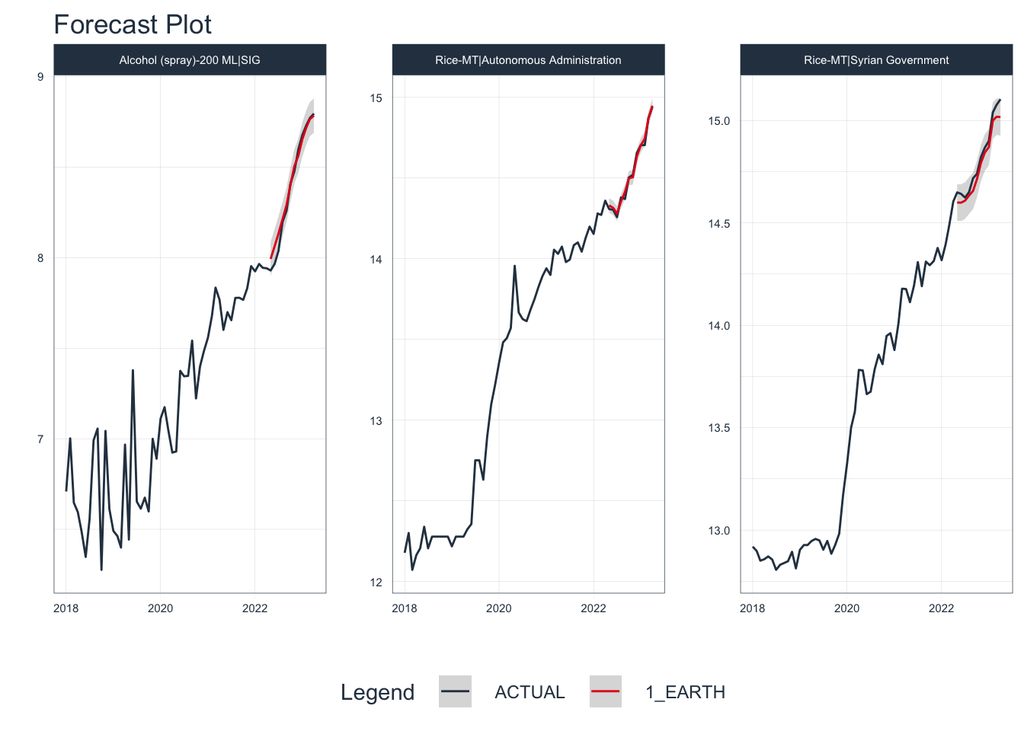

```r
  test_fc = calib_tbl %>%
    modeltime_forecast(
      new_data    = testing(splits),
      actual_data = round3_preds,
      conf_by_id  =TRUE
    )

  test_fc %>%
    dplyr::filter(id %in% sample(unique(id),3)) %>%
    group_by(id) %>%
    plot_modeltime_forecast(
      .facet_ncol  = 3,
      .interactive = FALSE
    )
```

All model predictions are then passed on to post-processing and model-selection.

```r
refit_tbl <- calib_tbl %>%
    modeltime_refit(data = round3_preds)

  mars_preds = refit_tbl %>%
    modeltime_forecast(
      new_data    = round3_preds,
      actual_data = round3_preds,
      conf_by_id  =TRUE
    )

  mars_preds = mars_preds %>%
    dplyr::select(key = .key, date = .index, value = .value, id) %>%
    tidyr::pivot_wider(names_from = key, values_from = value) %>%
    dplyr::group_by(id) %>%
    mutate(prediction_smoothed = slider::slide_dbl(prediction, mean, .before = 1, .after = 1)) %>%
    dplyr::rename(value = actual,
                  mars = prediction,
                  mars_smoothed = prediction_smoothed)

  round4_preds = base::merge(mars_preds, round3_preds)

  mars_fc = refit_tbl %>%
    modeltime_forecast(
      new_data    = round3_fc,
      actual_data = round3_preds,
      conf_by_id  =TRUE
    )

  fc_set_mars= mars_fc %>%
    dplyr::filter(.key != "actual") %>%
    dplyr::filter(!is.na(.value)) %>%
    dplyr::group_by(id) %>%
    mutate(prediction_smoothed = slider::slide_dbl(.value, mean, .before = 1, .after = 1)) %>%
    dplyr::rename(mars = .value,
                  mars_smoothed = prediction_smoothed) %>%
    dplyr::select(c(mars, mars_smoothed, date = .index, id))

  round4_fc = base::merge(round3_fc, fc_set_mars)

  head(round4_preds)
```

```
##         date                                               id    value     mars
## 1 2018-01-01 Alcohol (spray)-200 ML|Autonomous Administration 5.186154 5.234565
## 2 2018-01-01                       Alcohol (spray)-200 ML|SIG 6.708360 6.802491
## 3 2018-01-01                       Alcohol (spray)-200 ML|SSG 6.956704 7.005305
## 4 2018-01-01         Alcohol (spray)-200 ML|Syrian Government 6.855958 6.804406
## 5 2018-01-01              Apples-KG|Autonomous Administration 5.587249 5.628097
## 6 2018-01-01                                    Apples-KG|SIG 5.860786 5.795238
##   mars_smoothed      xgb xgb_smoothed      cub cub_smoothed    naive
## 1      6.018528 5.237465     6.019623 5.407777     5.446313 7.879994
## 2      6.347454 6.801781     6.347931 6.652985     7.670269 8.794976
## 3      6.870734 7.004547     6.870008 6.917867     8.020313 8.640720
## 4      6.479269 6.803695     6.479369 6.621081     7.633304 8.601456
## 5      6.075914 5.629864     6.076695 5.706731     7.011737 8.568456
## 6      5.689039 5.796525     5.690632 5.848098     7.576303 8.555837
```

## Model Selection

The best model is chosen for each commodity based on which model minimizes MAE.

```r
 best_fit = round4_preds %>%
    dplyr::group_by(id) %>%
    dplyr::summarize(mars = Metrics::mae(value, mars),
                     mars_smoothed = Metrics::mae(value, mars_smoothed),
                     xgb = Metrics::mae(value, xgb),
                     xgb_smoothed = Metrics::mae(value, xgb_smoothed),
                     cub = Metrics::mae(value, cub),
                     cub_smoothed = Metrics::mae(value, cub_smoothed)) %>%
    tidyr::pivot_longer(cols = c(mars:cub_smoothed), names_to = "mod_name", values_to = "mae") %>%
    group_by(id) %>%
    slice_min(order_by = mae)
```

```r
  final_preds = round4_preds %>%
    dplyr::select(-naive) %>%
    dplyr::group_by(id) %>%
    tidyr::pivot_longer(cols = c(mars:cub_smoothed),
                        names_to = "model", values_to = "preds") %>%
    base::merge(best_fit, all.x = TRUE) %>%
    dplyr::filter(model == mod_name) %>%
    dplyr::select(-c(model, mod_name, mae)) %>%
    dplyr::mutate(value = exp(value)-1,
                  preds = exp(preds)-1)
  head(final_preds)
```

```
##                                                 id       date    value    preds
## 1 Alcohol (spray)-200 ML|Autonomous Administration 2018-01-01 177.7797 186.6474
## 2 Alcohol (spray)-200 ML|Autonomous Administration 2018-05-01 247.7454 219.3628
## 3 Alcohol (spray)-200 ML|Autonomous Administration 2018-09-01 341.7226 296.6275
## 4 Alcohol (spray)-200 ML|Autonomous Administration 2019-01-01 638.7091 609.3917
## 5 Alcohol (spray)-200 ML|Autonomous Administration 2019-09-01 442.8909 429.0915
## 6 Alcohol (spray)-200 ML|Autonomous Administration 2020-01-01 449.8316 440.3043
```

Then, the optimal model’s forecast is chosen for each commodity.

```r
  final_forecasts = round4_fc%>%
    dplyr::select(-naive) %>%
    dplyr::group_by(id) %>%
    tidyr::pivot_longer(cols = c(mars_smoothed:cub),
                        names_to = "model", values_to = "preds") %>%
    base::merge(best_fit, all.x = TRUE) %>%
    dplyr::filter(model == mod_name) %>%
    dplyr::select(-c(model, mod_name, mae)) %>%
    dplyr::mutate(preds = exp(preds)-1)

  head(final_forecasts)
```

```
##                                                 id       date     preds
## 1 Alcohol (spray)-200 ML|Autonomous Administration 2023-05-01  2902.754
## 2 Alcohol (spray)-200 ML|Autonomous Administration 2023-09-01  3112.310
## 3 Alcohol (spray)-200 ML|Autonomous Administration 2024-01-01 14407.943
## 4 Alcohol (spray)-200 ML|Autonomous Administration 2023-08-01  3548.915
## 5 Alcohol (spray)-200 ML|Autonomous Administration 2023-12-01  4552.647
## 6 Alcohol (spray)-200 ML|Autonomous Administration 2023-07-01  2543.097
```

The final set is created below:

```r
  final_preds = final_preds %>%
    dplyr::select(c(id, date, actual = value, predicted = preds)) %>%
    tidyr::pivot_longer(cols = c(actual, predicted), names_to = "key", values_to = "price")


  final_forecasts = final_forecasts %>%
    dplyr::select(c(id, date, price = preds)) %>%
    dplyr::mutate(key = "forecast")

  mod_set = rbind(final_preds, final_forecasts) %>%
    separate_wider_delim(id, delim = "|", names = c("commodity", "ZOC"))

  head(mod_set)
```

```
## # A tibble: 6 × 5
##   commodity              ZOC                       date       key       price
##   <chr>                  <chr>                     <date>     <chr>     <dbl>
## 1 Alcohol (spray)-200 ML Autonomous Administration 2018-01-01 actual     178.
## 2 Alcohol (spray)-200 ML Autonomous Administration 2018-01-01 predicted  187.
## 3 Alcohol (spray)-200 ML Autonomous Administration 2018-05-01 actual     248.
## 4 Alcohol (spray)-200 ML Autonomous Administration 2018-05-01 predicted  219.
## 5 Alcohol (spray)-200 ML Autonomous Administration 2018-09-01 actual     342.
## 6 Alcohol (spray)-200 ML Autonomous Administration 2018-09-01 predicted  297.
```

```r
  write_csv(mod_set, "Syria_forecasted.csv")
```